# Prueba2

```python
#cargar librerias necesarias
import numpy as np
import matplotlib.pyplot as plt
from sklearn.linear_model import LinearRegression
from sklearn import metrics
from sklearn.metrics import mean_squared_error
from sklearn.model_selection import train_test_split
import time
%matplotlib inline
```

```python
import sys
np.set_printoptions(threshold=sys.maxsize)
```

```python
data = np.loadtxt('Trabajo_grado/Datos/Dataset.data',delimiter=',')
X = data[:,:3]
Y = data[:,3:100]
```

```python
x_train, x_test, y_train, y_test = train_test_split(X,Y,test_size=0.2)
print('x train:\n', x_train)
print('y train: \n',y_train)
print('x test: \n',x_test)
print('y test: \n',y_test)
```

[output not shown]

[output cut: 169 more lines]

[output not shown]

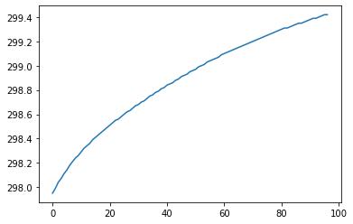

```python
plt.plot(y_test[1,:])
```

```python
model = LinearRegression()
```

El coeficiente de determinación R2 determina la calidad del modelo para replicar los resultados, y la proporción de variación de los resultados que puede explicarse por el modelo.

El rango de R2 está entre 0 y 1, siendo 1 lo mejor. Para medir el coeficiente de determinación R2 de la regresión lineal usaremos el método score.

```python
#train
start = time.time()#iniciar medida del tiempo
model.fit(x_train,y_train)
score_train = model.score(x_train, y_train);score_train
end = time.time() #tomar el tiempo final
total = end - start
print('Tiempo total entrenamiento: ' + str(total) + ' segundos')
print('Score test: %f' % score_train,"\n")
```

```
Tiempo total entrenamiento: 0.03425478935241699 segundos
Score test: 0.977268
```

```python
#test
start = time.time()#iniciar medida del tiempo
y_pred = model.predict(x_test)
score_test = model.score(x_test, y_test)
end = time.time() #tomar el tiempo final
total = end - start
print('Tiempo total validación: ' + str(total) + ' segundos')
print('Score test: %f' % score_test,"\n")
y_pred
```

```
Tiempo total validación: 0.00099945068359375 segundos
Score test: 0.924919
```

```
array([[297.95      , 297.99155668, 298.03291016, 298.06651212,
        298.10388599, 298.13285644, 298.16607034, 298.19762213,
        298.22703681, 298.25295011, 298.27956505, 298.30735237,
        298.32983872, 298.35438161, 298.3757502 , 298.39807109,
        298.42399819, 298.44489676, 298.4617797 , 298.48227397,
        298.50245332, 298.52021876, 298.53795903, 298.55456949,
        298.57349483, 298.59370526, 298.60969224, 298.62544395,
        298.64420647, 298.66019072, 298.67471845, 298.69192941,
        298.70969764, 298.72322636, 298.73925494, 298.7538412 ,
        298.77056723, 298.78487836, 298.80003585, 298.81622887,
        298.82887197, 298.84508936, 298.8591268 , 298.87276729,
        298.88707181, 298.90204179, 298.91606578, 298.93009282,
        298.94446695, 298.95673256, 298.96851842, 298.98451363,
        298.99852046, 299.00947041, 299.02157219, 299.03728298,
        299.0476874 , 299.05868657, 299.07198505, 299.08309331,
        299.09468268, 299.10720134, 299.11893934, 299.12893934,
        299.14173294, 299.15439515, 299.16385166, 299.17404816,
        299.18533048, 299.19682392, 299.20682392, 299.21662743,
        299.22608394, 299.2370831 , 299.2470831 , 299.25530009,
        299.26530009, 299.27530009, 299.28530009, 299.29530009,
        299.30343488, 299.31077755, 299.31856282, 299.32856282,
        299.33856282, 299.34831003, 299.35534036, 299.36426571,
        299.37204915, 299.38029021, 299.3885072 , 299.39698269,
        299.40574887, 299.41072182, 299.41905877, 299.42896287,
        299.4360489 ],
       [297.95      , 297.99328603, 298.03763007, 298.07078634,
        298.11036352, 298.1395335 , 298.17330768, 298.20686418,
        298.23463689, 298.26190498, 298.28881883, 298.31628451,
        298.33856414, 298.36368272, 298.38588713, 298.40750998,
        298.43305807, 298.45509591, 298.4712317 , 298.49225648,
        298.51160333, 298.52810223, 298.54649537, 298.56493898,
        298.58325512, 298.60035286, 298.61747345, 298.63293786,
        298.6531673 , 298.66465291, 298.68306949, 298.69723791,
        298.71442277, 298.72937738, 298.74450605, 298.76010053,
        298.77585255, 298.79262405, 298.80550313, 298.82219843,
        298.83256187, 298.84923416, 298.8639789 , 298.87629236,
        298.89100964, 298.906424  , 298.91757815, 298.9335605 ,
        298.94768223, 298.95980989, 298.96987938, 298.98906076,
        299.00193952, 299.01200857, 299.02427364, 299.03598308,
        299.04960848, 299.05922217, 299.07278052, 299.08249515,
```

[output cut: 45 more lines]

```
        298.89624576, 298.91340823, 298.92761418, 298.94255693,
        298.95770776, 298.97523884, 298.98553084, 299.00299945,
        299.01775799, 299.03155314, 299.0422203 , 299.06025131,
        299.07471443, 299.08734922, 299.09896654, 299.11263   ,
        299.12613004, 299.13710996, 299.15150936, 299.16225383,
        299.17447374, 299.1889897 , 299.20055386, 299.21055386,
        299.22409401, 299.23827478, 299.24838347, 299.25683073,
        299.26730627, 299.27983237, 299.28983237, 299.30138511,
        299.3114938 , 299.32247373, 299.33247373, 299.34125455,
        299.35125455, 299.36125455, 299.37125455, 299.38125455,
        299.38949475, 299.39725609, 299.4035355 , 299.4135355 ,
        299.4235355 , 299.43466121, 299.44312491, 299.45190501,
        299.45982588, 299.46578659, 299.47456741, 299.48453065,
        299.49210076, 299.49969532, 299.50649448, 299.51565602,
        299.52278991]])
```

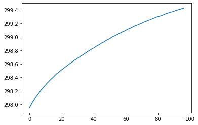

```python
plt.plot(y_pred[1,:])
```

```python
print(model.coef_)
```

```
[[ 1.62613238e-31  2.77116697e-31  2.33216205e-27]
 [-1.02910688e-05 -4.26174124e-05 -2.98007407e-02]
 [-1.91756843e-05 -7.20483618e-05 -9.76478160e-03]
 [-2.67187278e-05 -9.53409081e-05 -4.14836930e-02]
 [-3.61514918e-05 -1.24497392e-04 -3.20836384e-02]
 [-4.14823587e-05 -1.61489249e-04 -9.86268090e-02]
 [-4.56081812e-05 -1.69286819e-04 -8.88354607e-02]
 [-5.23210032e-05 -1.93740696e-04 -8.39874486e-02]
 [-5.91744007e-05 -2.05809249e-04 -1.11221785e-01]
 [-6.25229953e-05 -2.35367193e-04 -1.47543399e-01]
 [-6.71293467e-05 -2.46672651e-04 -1.49172887e-01]
 [-7.45143837e-05 -2.60673437e-04 -1.55335879e-01]
 [-7.65933795e-05 -2.73419897e-04 -1.81991392e-01]
 [-8.22588982e-05 -2.97785443e-04 -2.07441921e-01]
 [-8.33394538e-05 -3.05805508e-04 -2.08126984e-01]
 [-8.54863327e-05 -3.11961664e-04 -2.26093422e-01]
 [-9.20192717e-05 -3.22110580e-04 -2.27422693e-01]
 [-9.54162154e-05 -3.39717871e-04 -2.36328730e-01]
 [-9.59745408e-05 -3.59703587e-04 -2.98784763e-01]
 [-9.69439611e-05 -3.67743796e-04 -3.05496968e-01]
 [-1.01769201e-04 -3.75112793e-04 -3.15984642e-01]
 [-1.05682844e-04 -3.81138608e-04 -3.35143539e-01]
 [-1.05240625e-04 -3.86497537e-04 -3.39580704e-01]
 [-1.08671122e-04 -4.12947846e-04 -3.58923997e-01]
 [-1.08824700e-04 -4.14060680e-04 -3.71909504e-01]
 [-1.12158104e-04 -4.07739376e-04 -3.94704510e-01]
 [-1.16931320e-04 -4.30015454e-04 -4.09138465e-01]
 [-1.15745235e-04 -4.33578762e-04 -4.29266412e-01]
 [-1.20910277e-04 -4.45835602e-04 -4.09858697e-01]
 [-1.22518967e-04 -4.34475103e-04 -4.52628847e-01]
 [-1.22018248e-04 -4.58817354e-04 -4.49019879e-01]
 [-1.26106098e-04 -4.60314489e-04 -4.87190749e-01]
 [-1.30140048e-04 -4.54120827e-04 -4.61890101e-01]
 [-1.31338278e-04 -4.80020858e-04 -4.97905606e-01]
 [-1.32421554e-04 -4.86686058e-04 -5.25956865e-01]
 [-1.32651898e-04 -4.97005561e-04 -5.33674291e-01]
 [-1.35154234e-04 -4.91693591e-04 -5.25060412e-01]
 [-1.37356203e-04 -5.20574231e-04 -5.45519002e-01]
 [-1.39445708e-04 -5.14520545e-04 -5.60205412e-01]
 [-1.41777988e-04 -5.21654677e-04 -5.58443130e-01]
```

[output cut: 42 more lines]

```
 [-1.93279015e-04 -7.15845782e-04 -1.05787327e+00]
 [-1.93279015e-04 -7.15845782e-04 -1.05787327e+00]
 [-1.93279015e-04 -7.15845782e-04 -1.05787327e+00]
 [-1.96002879e-04 -7.22990756e-04 -1.04722937e+00]
 [-1.97592593e-04 -7.35421631e-04 -1.06567950e+00]
 [-1.97746171e-04 -7.36534466e-04 -1.07866501e+00]
 [-1.97128622e-04 -7.40775737e-04 -1.09841914e+00]
 [-1.98025687e-04 -7.27024791e-04 -1.10927287e+00]
 [-1.98555298e-04 -7.35849714e-04 -1.14058656e+00]
 [-1.99292586e-04 -7.41784898e-04 -1.11612272e+00]
 [-2.00892640e-04 -7.35882249e-04 -1.13091920e+00]
 [-2.00418329e-04 -7.59569879e-04 -1.16731249e+00]
 [-2.00449578e-04 -7.51760063e-04 -1.18306961e+00]
 [-2.01315394e-04 -7.45818933e-04 -1.17816622e+00]
 [-2.03650707e-04 -7.52744158e-04 -1.22088390e+00]]
```

```python
print(model.intercept_)
```

```
[297.95       298.0943461  298.18785695 298.29482531 298.39292379
 298.52292528 298.57397496 298.65374227 298.73939737 298.83185153
 298.88902054 298.96376998 299.02436392 299.11215445 299.14643956
 299.19480872 299.25735495 299.31525868 299.39451847 299.43133457
 299.48444526 299.53571288 299.56009876 299.62960466 299.65849421
 299.69948051 299.76612834 299.7937193  299.83286838 299.87038135
 299.90588977 299.96462014 299.97556844 300.04333922 300.08821113
 300.11925624 300.13471094 300.20038728 300.22665446 300.25813989
 300.32839371 300.34858118 300.35944194 300.43196236 300.45945372
 300.52413282 300.49896484 300.56555335 300.58299588 300.64255635
 300.6659229  300.6678759  300.70791588 300.77996806 300.77986429
 300.81425659 300.84918731 300.88236023 300.91272807 300.94439891
 300.97649552 300.98712564 301.04422256 301.05422256 301.08486822
 301.11769677 301.14975993 301.15102987 301.16289071 301.21287973
 301.22287973 301.24160979 301.27367295 301.30684587 301.31684587
 301.35606512 301.36606512 301.37606512 301.38606512 301.39606512
 301.42293204 301.46468228 301.47680552 301.48680552 301.49680552
 301.51775027 301.55547597 301.57436551 301.59665275 301.60099637
 301.64021562 301.6422056  301.6604142  301.71110808 301.72145245
 301.72545169 301.77577518]
```

```python
mse = mean_squared_error(y_test, y_pred)
print("MSE: ",mse)
```

```
MSE:  5.123856231509013e-05
```

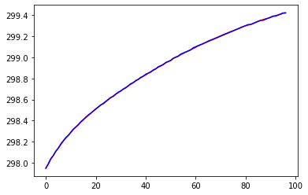

```python
plt.plot(y_pred[1,:],"r",y_test[1,:],"b")
```

```python
e = y_pred - y_test;e
```

```
array([[-5.68434189e-14,  1.55668023e-03,  2.91016135e-03,
        -3.48788250e-03,  3.88599131e-03,  2.85644097e-03,
         6.07033879e-03,  7.62212622e-03,  7.03681430e-03,
         2.95010714e-03,  9.56504883e-03,  7.35236648e-03,
         9.83871603e-03,  4.38161331e-03,  5.75020315e-03,
         8.07109392e-03,  1.39981933e-02,  4.89676201e-03,
         1.77969974e-03,  2.27397486e-03,  1.24533239e-02,
         1.02187602e-02,  7.95902745e-03,  4.56948656e-03,
         3.49483295e-03,  1.37052613e-02,  9.69224120e-03,
         5.44395050e-03,  4.20647201e-03,  1.01907176e-02,
         4.71845149e-03,  1.19294068e-02,  9.69764380e-03,
         1.32263578e-02,  9.25493947e-03,  1.38412031e-02,
         1.05672260e-02,  4.87836278e-03,  1.00358509e-02,
         1.62288691e-02,  8.87196624e-03,  1.50893645e-02,
         9.12680270e-03,  1.27672917e-02,  7.07181362e-03,
         1.20417927e-02,  1.60657803e-02,  1.00928243e-02,
         1.44669526e-02,  6.73255698e-03,  8.51841828e-03,
         1.45136306e-02,  1.85204611e-02,  9.47041244e-03,
         1.15721877e-02,  1.72829841e-02,  7.68740112e-03,
         8.68656733e-03,  1.19850505e-02,  1.30933110e-02,
         1.46826819e-02,  1.72013408e-02,  8.93933846e-03,
         8.93933846e-03,  1.17329360e-02,  1.43951548e-02,
         1.38516648e-02,  1.40481551e-02,  1.53304766e-02,
         1.68239180e-02,  1.68239180e-02,  1.66274276e-02,
         1.60839376e-02,  1.70831038e-02,  1.70831038e-02,
         1.53000925e-02,  1.53000925e-02,  1.53000925e-02,
         1.53000925e-02,  1.53000925e-02,  1.34348779e-02,
         1.07775519e-02,  8.56282029e-03,  8.56282029e-03,
         8.56282029e-03,  1.83100267e-02,  1.53403612e-02,
         1.42657076e-02,  1.20491529e-02,  1.02902074e-02,
         8.50719611e-03,  1.69826915e-02,  1.57488688e-02,
         1.07218178e-02,  9.05876518e-03,  1.89628723e-02,
         1.60489041e-02],
       [-5.68434189e-14,  3.28602863e-03, -2.36993182e-03,
         7.86336858e-04,  3.63524890e-04, -4.66497885e-04,
        -6.69232060e-03, -3.13582370e-03, -5.36310779e-03,
         1.90497939e-03, -1.18116933e-03, -3.71548759e-03,
        -1.43585717e-03,  3.68271651e-03, -4.11287448e-03,
        -2.49002177e-03,  3.05806692e-03,  5.09590829e-03,
         1.23170478e-03,  2.25648229e-03,  1.60333425e-03,
```

[output cut: 77 more lines]

```
         8.96654295e-03,  2.62999787e-03,  6.13003538e-03,
         7.10996350e-03,  1.50936468e-03,  2.25382769e-03,
         4.47373595e-03,  8.98969828e-03,  1.05538587e-02,
         5.53858665e-04,  4.09401240e-03,  8.27477766e-03,
         8.38346795e-03,  6.83072509e-03,  7.30626706e-03,
         9.83236709e-03,  9.83236709e-03,  1.13851100e-02,
         1.14938002e-02,  1.24737284e-02,  1.24737284e-02,
         1.12545484e-02,  1.12545484e-02,  1.12545484e-02,
         1.12545484e-02,  1.12545484e-02,  9.49474622e-03,
         7.25608804e-03,  3.53550089e-03,  3.53550089e-03,
         3.53550089e-03,  4.66121043e-03,  1.31249123e-02,
         1.19050082e-02,  9.82588197e-03,  5.78658574e-03,
         4.56740575e-03,  1.45306489e-02,  1.21007565e-02,
         9.69532040e-03,  6.49448326e-03,  5.65602416e-03,
         1.27899067e-02]])
```

PRUEBA CON VALORES NUEVOS EN X

Crear un nuevo conjunto de datos con valores aleatorios de cada parametro dentro del rango especifico. Probar con esos nuevos datos el entrenamiento realiZado anteriormente.

```python
from numpy import random
```

```python
cp_org  = 4184.1              # Calor específico del agua    [J/kg.K]
rho_org  = 998.20             # Densidad del agua        [kg/m^3]
k_org    = 0.6034             # Condutividad térmica del agua    [W/m.K]
```

```python
#CÓDIGO DE MATLAB - INTENTAR TRADUCIR A PYTHON:
#cp = cp_org+0.1*cp_org.*randn(20,1)
#rho = rho_org+0.1*rho_org.*randn(20,1)
#k = k_org+0.1*k_org.*randn(20,1)
```

```python
#def Calcular_limites(a,i):
#    Lim_Inf = a - (a*0.15)
#    Lim_Sup = a + (a*0.15)
#   Vec = (Lim_Sup - Lim_Inf)*np.array(1,i) + Lim_Inf
#   return Vec
```

```python
#for i in range(1,10):
#    Vec_Cp = Calcular_limites(cp_org,i)
#    Vec_rho = Calcular_limites(rho_org,i)
#    Vec_k = Calcular_limites(k_org,i)
```

```python
for i in range(1,20):

    cp = np.linspace(cp_org-0.1*cp_org, cp_org+0.1*cp_org, i)
    rho = np.linspace(rho_org-0.1*rho_org, rho_org+0.1*rho_org, i)
    k = np.linspace(k_org-0.1*k_org, k_org+0.1*k_org, i)

print(cp)
print(rho)
print(k)
```

```
[3765.69 3812.18 3858.67 3905.16 3951.65 3998.14 4044.63 4091.12 4137.61
 4184.1  4230.59 4277.08 4323.57 4370.06 4416.55 4463.04 4509.53 4556.02
 4602.51]
[ 898.38        909.47111111  920.56222222  931.65333333  942.74444444
  953.83555556  964.92666667  976.01777778  987.10888889  998.2
 1009.29111111 1020.38222222 1031.47333333 1042.56444444 1053.65555556
 1064.74666667 1075.83777778 1086.92888889 1098.02      ]
[0.54306    0.54976444 0.55646889 0.56317333 0.56987778 0.57658222
 0.58328667 0.58999111 0.59669556 0.6034     0.61010444 0.61680889
 0.62351333 0.63021778 0.63692222 0.64362667 0.65033111 0.65703556
 0.66374   ]
```

```python
new_x = []
new_x.append(cp)
new_x.append(rho)
new_x.append(k)

new_x = np.array(new_x)
new_x = new_x.T
new_x
```

```
array([[3.76569000e+03, 8.98380000e+02, 5.43060000e-01],
       [3.81218000e+03, 9.09471111e+02, 5.49764444e-01],
       [3.85867000e+03, 9.20562222e+02, 5.56468889e-01],
       [3.90516000e+03, 9.31653333e+02, 5.63173333e-01],
       [3.95165000e+03, 9.42744444e+02, 5.69877778e-01],
       [3.99814000e+03, 9.53835556e+02, 5.76582222e-01],
       [4.04463000e+03, 9.64926667e+02, 5.83286667e-01],
       [4.09112000e+03, 9.76017778e+02, 5.89991111e-01],
       [4.13761000e+03, 9.87108889e+02, 5.96695556e-01],
       [4.18410000e+03, 9.98200000e+02, 6.03400000e-01],
       [4.23059000e+03, 1.00929111e+03, 6.10104444e-01],
       [4.27708000e+03, 1.02038222e+03, 6.16808889e-01],
       [4.32357000e+03, 1.03147333e+03, 6.23513333e-01],
       [4.37006000e+03, 1.04256444e+03, 6.30217778e-01],
       [4.41655000e+03, 1.05365556e+03, 6.36922222e-01],
       [4.46304000e+03, 1.06474667e+03, 6.43626667e-01],
       [4.50953000e+03, 1.07583778e+03, 6.50331111e-01],
       [4.55602000e+03, 1.08692889e+03, 6.57035556e-01],
       [4.60251000e+03, 1.09802000e+03, 6.63740000e-01]])
```

```python
np.savetxt('new_x.data', new_x, delimiter =",", fmt="%s")
```

```python
#test
start = time.time()#iniciar medida del tiempo
y_pred_new = model.predict(new_x)
score_test_new = model.score(new_x, y_pred_new)
end = time.time() #tomar el tiempo final
total = end - start
print('Tiempo total validación: ' + str(total) + ' segundos')
print('Score test: %f' % score_test_new,"\n")
y_pred_new
```

```
Tiempo total validación: 0.0029935836791992188 segundos
Score test: 1.000000
```

```
array([[297.95      , 298.0011229 , 298.0456176 , 298.08603037,
        298.12751917, 298.16807659, 298.20190181, 298.2370546 ,
        298.2712699 , 298.30483521, 298.33361662, 298.3646314 ,
        298.39146978, 298.42221504, 298.44485402, 298.46985128,
        298.49795703, 298.52241437, 298.54769954, 298.56999681,
        298.59262155, 298.6133337 , 298.63216083, 298.65448156,
        298.67474111, 298.69647473, 298.71729722, 298.73522272,
        298.75445011, 298.77288454, 298.7903698 , 298.81163253,
        298.82669425, 298.84712622, 298.86669745, 298.8834133 ,
        298.898895  , 298.91922338, 298.93508503, 298.95233568,
        298.97203823, 298.98701483, 299.00169733, 299.02171761,
        299.03744486, 299.05686469, 299.06641604, 299.08678254,
        299.09971744, 299.11803106, 299.13200162, 299.1460478 ,
        299.16170961, 299.17948514, 299.19075585, 299.20722323,
        299.22177669, 299.23448278, 299.24877731, 299.26247595,
        299.27693684, 299.28956194, 299.30562987, 299.31562987,
        299.32991949, 299.34393975, 299.35671192, 299.36622159,
        299.37681126, 299.39181462, 299.40181462, 299.41230496,
        299.42507713, 299.43778321, 299.44778321, 299.46007477,
        299.47007477, 299.48007477, 299.49007477, 299.50007477,
        299.51055576, 299.52250561, 299.53138648, 299.54138648,
        299.55138648, 299.56143537, 299.57198753, 299.58224708,
        299.59232186, 299.59974676, 299.61203832, 299.61920518,
        299.62865592, 299.64009167, 299.64877749, 299.65751657,
        299.66962624],
       [297.95      , 297.999972  , 298.04386156, 298.08345265,
        298.12424257, 298.16369574, 298.19730831, 298.23191031,
        298.26549055, 298.29832884, 298.32675978, 298.35723463,
        298.38365627, 298.41369727, 298.43619247, 298.46090119,
        298.48858174, 298.51262617, 298.53724498, 298.55936301,
        298.58161138, 298.6019463 , 298.62070481, 298.642443  ,
        298.66259601, 298.68409194, 298.70434869, 298.72215486,
        298.7411363 , 298.7593352 , 298.77659795, 298.79739812,
        298.81251062, 298.83235816, 298.85161704, 298.86815598,
        298.88363801, 298.90340654, 298.91913973, 298.93621464,
        298.9552931 , 298.97020537, 298.98493505, 299.00430718,
        299.0198892 , 299.03875027, 299.04873025, 299.06852611,
        299.08140536, 299.09920976, 299.11306432, 299.1272598 ,
        299.14262065, 299.15972609, 299.17113723, 299.18738331,
        299.20168521, 299.21413861, 299.22823471, 299.24171147,
```

[output cut: 420 more lines]

```
        298.6706259 , 298.68444454, 298.6999763 , 298.70832989,
        298.7214429 , 298.7308051 , 298.74807186, 298.7581668 ,
        298.7701    , 298.77924766, 298.79113022, 298.80786378,
        298.81810822, 298.82382227, 298.83762064, 298.85010471,
        298.86012989, 298.86828779, 298.87901048, 298.8887153 ,
        298.89925714, 298.91232557, 298.91927594, 298.92927594,
        298.93993088, 298.94977153, 298.95825681, 298.96959752,
        298.97990472, 298.98713348, 298.99713348, 299.00579277,
        299.01427805, 299.02243595, 299.03243595, 299.03874358,
        299.04874358, 299.05874358, 299.06874358, 299.07874358,
        299.08558326, 299.09091079, 299.09907113, 299.10907113,
        299.11907113, 299.12669873, 299.13121232, 299.1395541 ,
        299.146915  , 299.15502462, 299.16133225, 299.16964953,
        299.17715407, 299.1798658 , 299.18818306, 299.19797543,
        299.20159314]])
```

```python
np.savetxt('y_pred_new.data', y_pred_new, delimiter=",", fmt="%s")
```

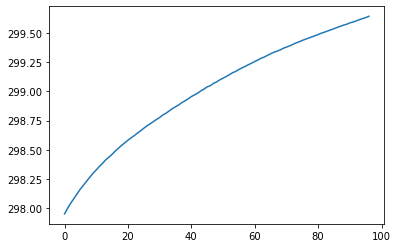

```python
plt.plot(y_pred_new[1,:])
```

NOTA: El problema de generar datos aleatorios con una desviación estandar de +/- 10% no está resuelto. Se debe encontrar la forma de generar datos aletarios en ese rango para cada parametro.

VERIFICAR Y QUE SALIÓ DE LAS SIMULACIONES CON LOS NUEVOS PARAMETROS DE NEW_X Y COMPARAR CON LA Y_PRED DEL MODELO DE REGRESIÓN

```python
data1 = np.loadtxt('Trabajo_grado/Datos/temp_newX.data',delimiter=',')
Y_real_newX = data1[:,:] #Salidas que dieron tras correr el modelo en MATLAB con los parametros X generados aleatoriamente.
```

```python
Y_real_newX[1]
```

```
array([297.95, 298.  , 298.04, 298.08, 298.12, 298.16, 298.2 , 298.23,
       298.26, 298.29, 298.32, 298.35, 298.38, 298.41, 298.43, 298.46,
       298.49, 298.51, 298.53, 298.56, 298.58, 298.6 , 298.62, 298.64,
       298.66, 298.68, 298.7 , 298.72, 298.74, 298.76, 298.78, 298.79,
       298.81, 298.83, 298.85, 298.86, 298.88, 298.9 , 298.92, 298.93,
       298.95, 298.97, 298.98, 299.  , 299.02, 299.03, 299.05, 299.06,
       299.08, 299.09, 299.11, 299.12, 299.14, 299.15, 299.17, 299.18,
       299.2 , 299.21, 299.22, 299.24, 299.25, 299.27, 299.28, 299.29,
       299.3 , 299.32, 299.33, 299.34, 299.35, 299.37, 299.38, 299.39,
       299.4 , 299.41, 299.42, 299.43, 299.45, 299.46, 299.47, 299.48,
       299.49, 299.5 , 299.51, 299.52, 299.53, 299.54, 299.55, 299.56,
       299.57, 299.58, 299.59, 299.59, 299.6 , 299.61, 299.62, 299.63,
       299.64])
```

```python
y_pred_new[1]
```

```
array([297.95      , 297.999972  , 298.04386156, 298.08345265,
       298.12424257, 298.16369574, 298.19730831, 298.23191031,
       298.26549055, 298.29832884, 298.32675978, 298.35723463,
       298.38365627, 298.41369727, 298.43619247, 298.46090119,
       298.48858174, 298.51262617, 298.53724498, 298.55936301,
       298.58161138, 298.6019463 , 298.62070481, 298.642443  ,
       298.66259601, 298.68409194, 298.70434869, 298.72215486,
       298.7411363 , 298.7593352 , 298.77659795, 298.79739812,
       298.81251062, 298.83235816, 298.85161704, 298.86815598,
       298.88363801, 298.90340654, 298.91913973, 298.93621464,
       298.9552931 , 298.97020537, 298.98493505, 299.00430718,
       299.0198892 , 299.03875027, 299.04873025, 299.06852611,
       299.08140536, 299.09920976, 299.11306432, 299.1272598 ,
       299.14262065, 299.15972609, 299.17113723, 299.18738331,
       299.20168521, 299.21413861, 299.22823471, 299.24171147,
       299.25595464, 299.26860437, 299.28416577, 299.29416577,
       299.30825346, 299.32204152, 299.33457553, 299.34418692,
       299.3547609 , 299.36933233, 299.37933233, 299.38972095,
       299.40225496, 299.41470836, 299.42470836, 299.43666748,
       299.44666748, 299.45666748, 299.46666748, 299.47666748,
       299.48694618, 299.49852812, 299.50736896, 299.51736896,
       299.52736896, 299.53728334, 299.54750002, 299.55765303,
       299.56757704, 299.57503997, 299.58699909, 299.59422987,
       299.60357248, 299.61452357, 299.62318891, 299.63198651,
       299.6436244 ])
```

```python
e2 = Y_real_newX - y_pred_new
e2
```

```
array([[ 5.68434189e-14, -1.12290033e-03, -5.61759983e-03,
         3.96963295e-03,  2.48082556e-03,  1.92340699e-03,
        -1.90180909e-03,  2.94539874e-03, -1.26990074e-03,
        -4.83521263e-03, -3.61662275e-03, -4.63140479e-03,
        -1.46978257e-03, -2.21504026e-03, -4.85402387e-03,
         1.48721778e-04,  2.04297270e-03, -2.41436904e-03,
         2.30046322e-03,  3.19145266e-06, -2.62154914e-03,
        -3.33369658e-03, -2.16083393e-03, -4.48155721e-03,
        -4.74111470e-03,  3.52527112e-03,  2.70277918e-03,
         4.77727760e-03, -4.45010618e-03, -2.88453849e-03,
        -3.69799294e-04, -1.63253201e-03,  3.30574522e-03,
         2.87377600e-03, -6.69745454e-03, -3.41330185e-03,
         1.10500195e-03,  7.76622725e-04,  4.91497047e-03,
        -2.33568209e-03, -2.03822886e-03,  2.98516603e-03,
        -1.69732903e-03, -1.71761248e-03,  2.55513676e-03,
        -6.86468938e-03,  3.58396054e-03, -6.78253501e-03,
         2.82563295e-04,  1.96893870e-03, -2.00161560e-03,
         3.95219994e-03, -1.70961297e-03,  5.14862260e-04,
        -7.55853933e-04,  2.77676944e-03, -1.77669423e-03,
        -4.48277716e-03,  1.22268692e-03, -2.47595317e-03,
         3.06315523e-03,  4.38057284e-04, -5.62987397e-03,
         4.37012603e-03,  8.05102046e-05, -3.93975332e-03,
         3.28807659e-03,  3.77841390e-03,  3.18873565e-03,
        -1.81461904e-03, -1.81461904e-03,  7.69504366e-03,
         4.92287357e-03,  2.21679065e-03,  2.21679065e-03,
        -7.47658420e-05, -7.47658420e-05, -7.47658420e-05,
         9.92523416e-03,  9.92523416e-03,  9.44423550e-03,
         7.49439087e-03,  8.61352402e-03,  8.61352402e-03,
         8.61352402e-03,  8.56462681e-03,  8.01247324e-03,
         7.75291575e-03,  7.67813899e-03,  1.02532411e-02,
         7.96168461e-03,  7.94817317e-04,  1.34408467e-03,
        -9.16705106e-05,  1.22251009e-03,  2.48343161e-03,
         3.73757734e-04],
       [ 5.68434189e-14,  2.80033249e-05, -3.86155844e-03,
        -3.45265167e-03, -4.24257421e-03, -3.69574499e-03,
         2.69168659e-03, -1.91030905e-03, -5.49054933e-03,
        -8.32883837e-03, -6.75978431e-03, -7.23463227e-03,
        -3.65627473e-03, -3.69726981e-03, -6.19247400e-03,
        -9.01186349e-04,  1.41825569e-03, -2.62616770e-03,
        -7.24498209e-03,  6.36990953e-04, -1.61137984e-03,
```

[output cut: 572 more lines]

```
         2.23793551e-02,  1.98952949e-02,  1.98701095e-02,
         2.17122122e-02,  2.09895210e-02,  2.12847040e-02,
         2.07428605e-02,  1.76744348e-02,  2.07240562e-02,
         2.07240562e-02,  2.00691177e-02,  2.02284734e-02,
         2.17431896e-02,  2.04024776e-02,  2.00952801e-02,
         2.28665174e-02,  2.28665174e-02,  2.42072294e-02,
         2.57219457e-02,  2.75640483e-02,  1.75640483e-02,
         2.12564243e-02,  2.12564243e-02,  2.12564243e-02,
         2.12564243e-02,  2.12564243e-02,  2.44167416e-02,
         1.90892061e-02,  2.09288670e-02,  2.09288670e-02,
         2.09288670e-02,  2.33012705e-02,  1.87876832e-02,
         2.04459001e-02,  2.30850029e-02,  2.49753758e-02,
         1.86677518e-02,  2.03504654e-02,  2.28459254e-02,
         3.01341978e-02,  2.18169448e-02,  2.20245707e-02,
         2.84068551e-02]])
```

```python
mse_new = mean_squared_error(Y_real_newX, y_pred_new)
print("MSE: ",mse_new)
```

```
MSE:  8.298117711974493e-05
```

```python
data2 = np.loadtxt('Trabajo_grado/Datos/temp_newX1.txt',delimiter=',')
Y_real_newX1 = data2[:,:]
#Salidas que dieron tras correr el modelo en MATLAB con los parametros X generados aleatoriamente, pero con más digitos.
```

```python
Y_real_newX1[1]
```

```
array([297.95009123, 297.99765411, 298.0419395 , 298.08354932,
       298.12307636, 298.16047087, 298.19570388, 298.22997825,
       298.26295744, 298.29449061, 298.32457777, 298.35321891,
       298.38041404, 298.40758456, 298.43438251, 298.46031681,
       298.48538747, 298.50959447, 298.53293783, 298.55541754,
       298.5770336 , 298.59778601, 298.61789827, 298.63914749,
       298.65994402, 298.68028786, 298.70017901, 298.71961747,
       298.73860323, 298.75713631, 298.7752167 , 298.79284439,
       298.81064757, 298.82878022, 298.84670285, 298.86441545,
       298.88191802, 298.89921056, 298.91629308, 298.93316556,
       298.94982801, 298.96628043, 298.98277872, 298.99914271,
       299.01535006, 299.03140076, 299.04729482, 299.06303223,
       299.078613  , 299.09403713, 299.10930461, 299.12439061,
       299.13925467, 299.15394603, 299.16846468, 299.18281063,
       299.19698387, 299.2109844 , 299.22481224, 299.23846736,
       299.25194978, 299.26527822, 299.27844589, 299.29144596,
       299.30427842, 299.31694328, 299.32944053, 299.34177017,
       299.35393221, 299.36592665, 299.37775961, 299.38947983,
       299.40104372, 299.41245127, 299.42370249, 299.43479737,
       299.44573592, 299.45651814, 299.46714401, 299.47761356,
       299.48799631, 299.4983093 , 299.50849282, 299.51854687,
       299.52847144, 299.53826655, 299.54793217, 299.55746833,
       299.56687501, 299.57615222, 299.58543241, 299.59462232,
       299.60371039, 299.61269661, 299.621581  , 299.63036355,
       299.63904425])
```

```python
y_pred_new[1]
```

```
array([297.95      , 297.999972  , 298.04386156, 298.08345265,
       298.12424257, 298.16369574, 298.19730831, 298.23191031,
       298.26549055, 298.29832884, 298.32675978, 298.35723463,
       298.38365627, 298.41369727, 298.43619247, 298.46090119,
       298.48858174, 298.51262617, 298.53724498, 298.55936301,
       298.58161138, 298.6019463 , 298.62070481, 298.642443  ,
       298.66259601, 298.68409194, 298.70434869, 298.72215486,
       298.7411363 , 298.7593352 , 298.77659795, 298.79739812,
       298.81251062, 298.83235816, 298.85161704, 298.86815598,
       298.88363801, 298.90340654, 298.91913973, 298.93621464,
       298.9552931 , 298.97020537, 298.98493505, 299.00430718,
       299.0198892 , 299.03875027, 299.04873025, 299.06852611,
       299.08140536, 299.09920976, 299.11306432, 299.1272598 ,
       299.14262065, 299.15972609, 299.17113723, 299.18738331,
       299.20168521, 299.21413861, 299.22823471, 299.24171147,
       299.25595464, 299.26860437, 299.28416577, 299.29416577,
       299.30825346, 299.32204152, 299.33457553, 299.34418692,
       299.3547609 , 299.36933233, 299.37933233, 299.38972095,
       299.40225496, 299.41470836, 299.42470836, 299.43666748,
       299.44666748, 299.45666748, 299.46666748, 299.47666748,
       299.48694618, 299.49852812, 299.50736896, 299.51736896,
       299.52736896, 299.53728334, 299.54750002, 299.55765303,
       299.56757704, 299.57503997, 299.58699909, 299.59422987,
       299.60357248, 299.61452357, 299.62318891, 299.63198651,
       299.6436244 ])
```

```python
e3 = Y_real_newX1 - y_pred_new
e3
```

```
array([[ 9.34943901e-05, -2.31192991e-03, -1.47324105e-03,
         6.78995843e-04, -3.94322029e-04, -2.73763911e-03,
        -5.80320313e-04, -7.31051619e-04, -1.27479965e-03,
        -2.65595319e-03, -7.40598061e-04, -2.54600795e-03,
        -1.66240668e-03, -4.71372506e-03, -4.40467517e-05,
         1.37788301e-03, -1.19815977e-03, -1.01527304e-03,
        -2.54969012e-03, -1.98568903e-03, -2.63863459e-03,
        -2.26846482e-03, -6.68532156e-04, -1.35509528e-03,
        -4.39298108e-04, -1.45636312e-03, -2.02111140e-03,
        -1.47674812e-04, -3.49259298e-05,  4.11968929e-04,
         1.34922979e-03, -1.94978675e-03,  1.12465990e-03,
        -8.43923059e-04, -2.16671854e-03, -8.49082024e-04,
         1.48775440e-03, -1.23704343e-03,  2.89934500e-04,
         2.12960912e-04, -2.53085810e-03, -7.63686675e-04,
         1.33594185e-03, -2.04221090e-03, -1.28943985e-03,
        -4.39135305e-03,  2.21310092e-03, -2.15969945e-03,
         7.36985152e-04, -1.90716202e-03, -3.70347786e-04,
         9.08894280e-04,  3.58250322e-04, -2.48104079e-03,
         1.00954138e-03, -8.71472173e-04, -1.01350806e-03,
         5.16901498e-04,  2.83922765e-04,  4.71904586e-04,
        -2.77300411e-04,  6.51504267e-04, -2.02652281e-03,
         1.19311809e-03, -4.71201014e-05, -1.18826928e-03,
        -1.25158829e-03,  1.77733681e-03,  3.55598308e-03,
         7.50689630e-04,  2.78372279e-03,  4.20301498e-03,
         3.17983692e-03,  2.06210853e-03,  3.48982559e-03,
         2.46534868e-03,  3.57179077e-03,  4.51759539e-03,
         5.30276253e-03,  5.92729218e-03,  5.97951318e-03,
         4.48857498e-03,  5.93275819e-03,  6.12395186e-03,
         6.18128915e-03,  6.05587286e-03,  5.29334381e-03,
         4.68955447e-03,  4.13668946e-03,  6.09984696e-03,
         3.20398406e-03,  5.34082636e-03,  5.08946510e-03,
         2.74874312e-03,  3.05361872e-03,  3.20089704e-03,
        -1.26758221e-04],
       [ 9.12280381e-05, -2.31788596e-03, -1.92205802e-03,
         9.66696676e-05, -1.16620926e-03, -3.22487664e-03,
        -1.60443258e-03, -1.93205953e-03, -2.53311204e-03,
        -3.83822804e-03, -2.18201567e-03, -4.01572007e-03,
        -3.24223369e-03, -6.11271412e-03, -1.80996494e-03,
        -5.84373123e-04, -3.19427611e-03, -3.03169370e-03,
        -4.30715149e-03, -3.94547105e-03, -4.57778362e-03,
```

[output cut: 572 more lines]

```
         1.92320284e-02,  1.77525593e-02,  1.86040766e-02,
         2.11949932e-02,  2.10932273e-02,  2.18814470e-02,
         2.17047516e-02,  1.89041230e-02,  2.21131257e-02,
         2.21529370e-02,  2.14182395e-02,  2.13782661e-02,
         2.25740831e-02,  2.07949016e-02,  1.99296645e-02,
         2.20232920e-02,  2.12346820e-02,  2.17439224e-02,
         2.23233542e-02,  2.31263595e-02,  2.19834493e-02,
         2.44291023e-02,  2.30785663e-02,  2.16242175e-02,
         2.00660558e-02,  1.84040813e-02,  1.98443324e-02,
         2.27498484e-02,  2.27364101e-02,  2.07971600e-02,
         1.87717591e-02,  1.90326108e-02,  2.23213209e-02,
         2.16956845e-02,  2.19647831e-02,  2.13990010e-02,
         2.26239277e-02,  2.17751933e-02,  2.16686710e-02,
         2.62844265e-02,  2.52241222e-02,  2.26181623e-02,
         2.61163265e-02]])
```

```python
mse_new1 = mean_squared_error(Y_real_newX1, y_pred_new)
print("MSE: ",mse_new1)
```

```
MSE:  7.58494270173002e-05
```